# Catastrophic Climate Events That Caused US Economic Disorder

Gustavo I. Camilo

10 November 2019

```r
library(tidyverse)
```

```r
library(pacman)
library(ggplot2)
library(gridExtra)
```

## Loading and Reading Data

```r
StormData <- tbl_df(read.csv(file.choose(), header = T, sep = ","))
```

## Data

The data for this assignment come in the form of a comma-separated-value file compressed via the bzip2 algorithm to reduce its size. You can download the file from the course web site:

- [DataStorm](https://d396qusza40orc.cloudfront.net/repdata%2Fdata%2FStormData.csv.bz2)

There is also some documentation of the database available. Here you will find how some of the variables are constructed/defined.

- National Weather Service [Storm Data Documentation](https://d396qusza40orc.cloudfront.net/repdata%2Fpeer2_doc%2Fpd01016005curr.pdf)
- National Climatic Data Center Storm Events [FAQ](https://d396qusza40orc.cloudfront.net/repdata%2Fpeer2_doc%2FNCDC%20Storm%20Events-FAQ%20Page.pdf)

The events in the database start in the year 1950 and end in November 2011. In the earlier years of the database there are generally fewer events recorded, most likely due to a lack of good records. More recent years should be considered more complete.

## Data Processing

```r
StormData.fatalities <- subset(StormData, !StormData$FATALITIES == 0, select = c(EVTYPE, FATALITIES))


StormData.injuries <- subset(StormData,!StormData$INJURIES ==
    0, select = c(EVTYPE, INJURIES))


EUA_economic <- subset(StormData, !StormData$PROPDMG == 0 & !StormData$CROPDMG ==
    0, select = c(EVTYPE, PROPDMG, PROPDMGEXP, CROPDMG, CROPDMGEXP))
```

# 1- Across the United States, which types of events (as indicated in the ‘EVTYPE’ variable) are most harmful with respect to population health?

```r
StormData.fatalities <- aggregate(StormData.fatalities$FATALITIES, by = list(StormData.fatalities$EVTYPE),
    FUN = sum)
colnames(StormData.fatalities) <- c("EVTYPES", "FATALITIES")
 StormData.fatalities <- StormData.fatalities[order(StormData.fatalities$FATALITIES, decreasing = TRUE), ][1:10, ]

 #
 fatalities <- ggplot() + geom_bar(data = StormData.fatalities, aes(x = EVTYPES,
    y = FATALITIES, fill = interaction(FATALITIES, EVTYPES)), stat = "identity",
    show.legend = F) + theme(axis.text.x = element_text(angle = 30, hjust = 1)) +
    xlab("Catastrophic Events") + ylab("fatailities") + ggtitle("Top 10 Catastrophic Death Events") +
    theme(axis.text.x = element_text(angle = 30, hjust = 1)) + coord_flip()
```

```r
StormData.injuries <- aggregate(StormData.injuries$INJURIES, by = list(StormData.injuries$EVTYPE), FUN = sum)
colnames(StormData.injuries) <- c("EVTYPES","INJURIES")
StormData.injuries <- StormData.injuries[order(StormData.injuries$INJURIES, decreasing = T), ][1:10, ]

#
injuries <- ggplot() + geom_bar(data = StormData.injuries, aes(x = EVTYPES, y = INJURIES,
    fill = interaction(INJURIES, EVTYPES)), stat = "identity", show.legend = F) +
    theme(axis.text.x = element_text(angle = 30, hjust = 1)) + xlab("Catastrophic Events") +
    ylab("Injuries") + ggtitle("Top 10 Catastrophic Injury Events") +
    theme(axis.text.x = element_text(angle = 30, hjust = 1)) + coord_flip()
```

# Results

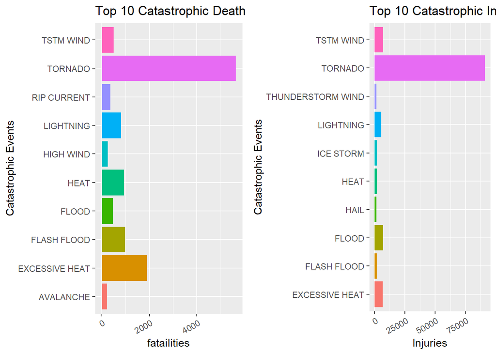

# 2 - Across the United States, which types of events have the greatest economic consequences?